# SCR lecture 1

06 September, 2019

## Welcome!

## Just in case…

Wifi:

- mi-guest / mileiden
- eduroam: ULCN@leidenuniv.nl / ULCN_password

Software:

- R: https://cran.r-project.org
- Rstudio: https://www.rstudio.com/products/rstudio/download/#download

## Topics for today

Setting Expectations for this course

A little bit of project management in RStudio

Basics in `R`

## Expectation Management

## Final Grade

- One assignment (1/3 of your final grade)
- Two exams (2/3 of your final grade) (average of both, unless the second one is highest, than only the last)

Each week the class meetings consists of a mixture of:

- Lectures
- Live-coding
- Exercises

## Let’s have a vote:

SCR Exam on January 06, 2020, or…

swap the SCR Exam with resit Mathematics for Statisticians? For example,  
- Resit Math for Stat is on January 06;  
- SCR Exam on January 16.

## Course structure

Participation is extremely important: programming is a skill, which you need to develop.

Q&A is extremely important: curiosity drives learning (how does this work? how do I solve this problem?)

A reason to come to the lecture: Slides are NOT standalone, but are supposed to support the storyline in the lecture…

## Why `R`?

1. Using `R` for statistical and data analysis procedures
   - [Data Camp Mostly](https://www.datacamp.com/home), [PluralSight](https://www.pluralsight.com), [`swirl`](https://swirlstats.com)
2. Adjust code for statistical procedures: Understanding `R`
   - R at CourseRa, Semester 2
3. Translate Statistical / Data Science problems into a solution with `R` code: Understanding `R` and Statistics.
   - for your / Internship / thesis / career…

**This course focusses on 2 and 3**

## Learning `R`

- Like learning a language
- Learn by doing (trial and error)
- Many “Quirks and Perks” that you have to get to know
- Building an `R` vocabulary:

  http://adv-r.had.co.nz/Vocabulary.html

## Learning `R` requires autonomy!

Stressing Autonomy

- Understanding errors and warnings
- `R` helpfiles
- Search engines
- [Stackoverflow](https://stackoverflow.com)
- Other community resources (such as Github)

Being able to read / use these takes practice

## You’re not alone!

- Your Lecturer (Maarten Kampert) / Teaching Assistant (Kevin Kloos)
- Class Colleagues
- the Elders (Year 2 and beyond)
- A selection of Communities:
  - [Amst-R-dam](https://www.meetup.com/amst-R-dam/)
  - [R Conferences](https://www.r-project.org/conferences/)
  - [RStudio Webinars](https://www.rstudio.com/resources/webinars/)
  - [rladies.org](https://www.meetup.com/rladies-amsterdam/?_cookie-check=UsgA24c_ofq0UUH9)

## `R`, in this course

The first half of the course will be about the basics in `R`:

- We’ll start with the more programming oriented content: data types and structures and control flow
- We’ll continue with the basics of statistics in `R`: analyses and visualization

The second half will deal with statistical computation:

- Statistical procedures and tests that have become feasible, *because* of computational power
- (Statistical) Algorithms

## Incremental

We’ll build knowledge incrementally

We’ll start off easy, **using** some of all the different tools in `R`

In the following weeks we’ll deepen your knowledge of `R` such that you can also apply it to a specialized (data science) topic

and eventually can translate Statistical (Data) Science problems into `R` code solutions.

## Cool Stuff

### The upsides…

## Networks D3

[interactive chart not shown]

## Google Visualization: Gapminder

## [VvS+OR 2015](http://pub.math.leidenuniv.nl/~kampertmmd/HighlightsVVSwide.html#21) and [googleVis](https://mages.github.io/googleVis_Tokyo_April_2014/#1)

## Smth Motivating: [Young Statisticians](http://youngstatisticians.nl)

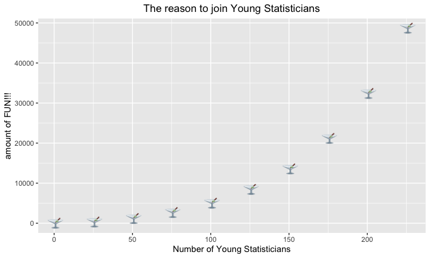

## `R` and beyond

These slides were made using `R` and **markdown**

For now use the html files on blackboard.

Later you’ll be able to recreate these from the source code that is also on the blackboard.

## `R` and beyond

E.g. build whole webpages with timelines on it:

http://timelyportfolio.github.io/rCharts_timeline_r/

More info http://rcharts.io

## Let’s start

## `R`, roughly

Two types of things in `R`

- object a.k.a variable (e.g. a collection of numbers): data types and structures
- functions (e.g. a way to take the square root of this collection of numbers): control flow / programming structures

## Data types

- logical (`TRUE`/`FALSE`)
- character (`"text"`)
- numeric (`2017`)
- integer (`1L`)

## Before we go to live coding / exercises

## Project management: reproducibility

Researchers should be able to reproduce your work

This means:

- Manage your workflow well
- Documentation
- Use (`R`) scripts

## Live coding 1

## Exercises part 1

## Functions

## Functions

Functions are (usually) executed for a particular purpose, which comes in two flavours:

1. You want its `return` value.
2. You want it to have **some other effect**.

The latter set of goals are (a bit misleadingly) called **side effects**: any effect that is not the return value is a side effect (e.g. a plotting window, or a file you save to the hard disk).

## Functions

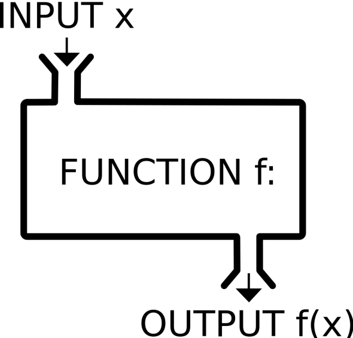

## Errors: `NA` and `NULL` (and `NaN`)

## Simply put

`NA` is information about absence

`NULL` is absence of information

`NaN` tells you it is Not A Number

## Live coding 2

## FAQ: About `=` vs. `<-`

[stackoverflow](https://stackoverflow.com/questions/1741820/what-are-the-differences-between-and-in-r)

Pro `<-`

```r
a <- c(x1 = -1, x2 = -4, x3 = -7)
a <- c(x1 <- -1, x2 <- -4, x3 <- -7)
```

Contra `<-`

```r
a < -3
```

```
## [1] FALSE  TRUE  TRUE
```

```r
a<-3
```

## Creating an object: data types and simple containers

Every object in `R` has a specific type of container, and a promise as to what the container contains

When you assign some value, or a set of values, to an object, `R` often decides for you what the type (mode) or the container (class) is

- type / mode: the thing the container contains
- container / class: how the container works

Note: in many cases, the way in which we interface with `R` is not necessarily how `R` stores the data! (almost everything in `R` is secretly a vector)

## Data types

These we’ve already seen:

- logical (`TRUE`/`FALSE`)
- character (`"text"`)
- numeric (`2017`)
- integer (`1L`)

## Data structures

- `vector`
- `matrix`
- `lists`
- `data.frames`

## Live coding 3: vectors

## Time for exercises

We’ve touched on most of the basic ingredients of `R`:

- Objects and functions
- Data types (e.g. numeric)
- Data structures (e.g. vectors)

Enough to get you working with each

## Exercises part 2

## Precursor to control flow

## Indexing and filtering

Using an index, we can access a particular element in a vector

The first element of a vector has index `1`.

Indexing is either:

- telling `R` which elements to DO select (using position *numbers* or entry *names*)
- telling `R` which elements to NOT select (using position *numbers*)
- or both (using *logicals*)

Filtering is usually done using logical vectors

## Live coding 4: indexing

## Exercises part 3

## Nearing the end of Today’s classes..

## Saving and loading your work

In order of priority (generally):

- saving and loading your script
- saving and loading workspace
- saving and loading your Rhistory (hardly done)

## Packages

Allmost all `R` functions come in **packages**.

Some packages are loaded into `R` upon startup (such as `base`, `stats` and `graphics`)

Most packages can be found on either CRAN, Bioconductor or Github

## Live coding 5: saving, loading, and working with packages

## Some last remarks

Just like in an ordinary language there are rules to the language

See comprehensive list of *code precedence* at the end of these slides

## Topics for next week

Amongst others:

- Reading data files (remember loading workspaces)
- Classes and advanced containers (`matrix` and `data.frame`)
- Details of functions. For example, scoping

## Homework

swirl, R Programming: The basics of programming in R, lessons **1** through **4**, and **6** through **9**.

Complete and finish Today’s exercises

Write down any questions you have: we will discuss these at the start of the next lecture!

Pay special attention to:

- the exercises
- **!! (vector) recycling !!**
- swirl lesson 2, about working directories and files
- swirl lesson 9, regarding functions, might be a bit tough

## More homework

After swirl read Matloff:

- chapter 1, (**not** 1.5)
- chapter 2, (**not** 2.9)
- chapter 3.1 through 3.7 (**not** 3.4)

Don’t just read the text, but also check the code in RStudio!

## That’s it for today!

## Precedence

### From highest to lowest

- `[ [[ (` Indexing
- `::` or `:::` access variables in a name space
- `$` or `@` component
- `^` exponentiation
- `-` or `+` unary minus and plus
- `:` sequence operator
- `%any%` special operators
- `*` or `/` multiply, divide
- `+` or `-` (binary) add, subtract

## Precedence

### From highest to lowest, continued.

- `<`, `>`, `<=`, `>=`, `==`, or `!=` ordering and comparison
- `!` negation
- `&` or `&&` and
- `|` or `||` or
- `~` as in formulae
- `->` or `->>` assignment
- `=` assignment
- `<-` or `<<-` assignment
- `?` help

## Extra course material

On the “use of” or “programming in” R:

- [swirl](http://swirlstats.com): `install.packages('swirl')`
- [DataCamp](https://www.datacamp.com/courses/free-introduction-to-r)
- [R/EdX](https://www.edx.org/course/introduction-r-data-science-microsoft-dat204x-2)
- [R/Coursera](https://www.mooc-list.com/course/r-programming-coursera)
- [R/MOOCs](https://www.mooc-list.com/tags/r-programing)